# Overview of the Dataset

This dataset, sourced from the educational sector, provides an in-depth look at college retention, a critical aspect of educational success. It encompasses a comprehensive range of data, capturing multifaceted aspects of student life and academic journey in a college setting. Key elements of this dataset include:

Academic Performance:

It details students' academic achievements, offering insights into grades and overall academic progress. This data is crucial for analyzing the academic aspects that contribute to student retention.

Student Demographics:

The dataset includes demographic information, shedding light on the diversity of the student body and its potential impact on academic outcomes.

Counseling and Advisory Engagement:

Data on students' participation in counseling and advisory sessions is a highlight of this dataset, indicating the level of support and guidance students receive.

Teaching Quality Feedback:

Students' perceptions of teaching quality are captured, providing an important perspective on the educational experience and its influence on student success and retention.

The dataset's comprehensive coverage of these areas makes it an invaluable resource for understanding the dynamics of student retention in colleges. It offers educational institutions and researchers the data needed to develop targeted strategies to enhance student engagement and academic achievement.

```python
import pandas as pd
import pandas as preprocessor
import matplotlib.pyplot as plt
import seaborn as sns
```

```python
# Loading the dataset
df = pd.read_excel('/content/COLLEGE_RET_SV.xlsx', sheet_name='DB')
```

```python
# Display the first few rows of the dataframe to understand its structur
df.head(10)
```

|  | ID | SEMESTER | MAJOR | ESTATUS | GENDER | ORIGIN | FIRSTPART_GRADE | SECONDPARTIAL_GRADE | FINALEXAM_GRADE | FINAL_GRADE | ... | TEACHEREVAL_Q8 | TEACHEREVAL_Q9 | TEACHEREVAL_Q10 | TEACHEREVAL_Q11 | TEACHEREVAL_Q12 | TEACHEREVAL_Q13 | TEACHEREVAL_Q14 | TEACHEREVAL_Q15 | TEACHEREVAL_Q16 | HONOR_FAULTS |
| --- | --- | --- | --- | --- | --- | --- | --- | --- | --- | --- | --- | --- | --- | --- | --- | --- | --- | --- | --- | --- | --- |
| 0 | 398471 | 8 | Business | ENROLLED | FEMALE | Local | 91.285714 | 89.285714 | 91.714286 | 85.428571 | ... | 7.000000 | 7.000000 | 6.000000 | 6.750000 | 7.000000 | 6.5 | 6.75 | 6.75 | 7.0 | 0 |
| 1 | 804181 | 5 | Engineering | ENROLLED | MALE | Local | 89.111111 | 92.555556 | 92.444444 | 91.444444 | ... | 7.000000 | 7.000000 | 7.000000 | 7.000000 | 7.000000 | 7.0 | 7.00 | 7.00 | 7.0 | 0 |
| 2 | 431091 | 1 | Psychology | NOT ENROLLED | FEMALE | Foreign | 98.545455 | 96.909091 | 98.363636 | 99.090909 | ... | 6.000000 | 6.285714 | 6.142857 | 6.142857 | 6.142857 | 6.0 | 6.00 | 6.00 | 6.0 | 0 |
| 3 | 741091 | 6 | Engineering | ENROLLED | FEMALE | Local | 89.555556 | 84.888889 | 90.777778 | 97.444444 | ... | 7.000000 | 7.000000 | 7.000000 | 7.000000 | 7.000000 | 7.0 | 7.00 | 7.00 | 7.0 | 0 |
| 4 | 274091 | 1 | Industrial Design | ENROLLED | FEMALE | Local | 83.300000 | 80.200000 | 79.800000 | 72.000000 | ... | 7.000000 | 7.000000 | 7.000000 | 7.000000 | 7.000000 | 7.0 | 7.00 | 7.00 | 7.0 | 0 |
| 5 | 575091 | 1 | Economics | ENROLLED | FEMALE | Local | 70.428571 | 76.416667 | 83.583333 | 83.500000 | ... | 6.714286 | 7.000000 | 7.000000 | 7.000000 | 7.000000 | 7.0 | 7.00 | 7.00 | 7.0 | 0 |
| 6 | 806091 | 8 | Physics | ENROLLED | MALE | Local | 93.750000 | 95.125000 | 93.125000 | 86.625000 | ... | 7.000000 | 7.000000 | 7.000000 | 7.000000 | 7.000000 | 7.0 | 7.00 | 7.00 | 7.0 | 0 |
| 7 | 336091 | 1 | Engineering Management | ENROLLED | FEMALE | Local | 98.250000 | 96.500000 | 96.166667 | 92.750000 | ... | 7.000000 | 7.000000 | 7.000000 | 7.000000 | 7.000000 | 7.0 | 7.00 | 7.00 | 7.0 | 0 |
| 8 | 697091 | 4 | Architecture | ENROLLED | FEMALE | Local | 96.428571 | 96.285714 | 97.285714 | 94.714286 | ... | 7.000000 | 7.000000 | 7.000000 | 7.000000 | 7.000000 | 7.0 | 7.00 | 7.00 | 7.0 | 0 |
| 9 | 538091 | 1 | Industrial Design | ENROLLED | FEMALE | Local | 95.285714 | 96.428571 | 95.857143 | 94.428571 | ... | 7.000000 | 7.000000 | 7.000000 | 7.000000 | 7.000000 | 7.0 | 7.00 | 7.00 | 7.0 | 0 |

10 rows × 37 columns

```python
# Display the data types of each column
df.dtypes
```

```
ID                           int64
SEMESTER                     int64
MAJOR                       object
ESTATUS                     object
GENDER                      object
ORIGIN                      object
FIRSTPART_GRADE            float64
SECONDPARTIAL_GRADE        float64
FINALEXAM_GRADE            float64
FINAL_GRADE                float64
ABSENCES_FIRSTPARTIAL      float64
ABSENCES_SECONDPARTIAL     float64
ABSENCES_THIRDDPARTIAL     float64
NUMCOURSES_ONLINE            int64
SCHOLARSHIP_PERCENT        float64
PASTDUE_BALANCE            float64
NUMBSESSIONS_ADVISORY        int64
NUMBSESSIONS_COUNSELING      int64
TUTORINGMATH_SESSIONS        int64
FORMATIVEPLAN_Q5             int64
TEACHEREVAL_Q1             float64
TEACHEREVAL_Q2             float64
TEACHEREVAL_Q3             float64
TEACHEREVAL_Q4             float64
TEACHEREVAL_Q5             float64
TEACHEREVAL_Q6             float64
TEACHEREVAL_Q7             float64
TEACHEREVAL_Q8             float64
TEACHEREVAL_Q9             float64
TEACHEREVAL_Q10            float64
TEACHEREVAL_Q11            float64
TEACHEREVAL_Q12            float64
TEACHEREVAL_Q13            float64
TEACHEREVAL_Q14            float64
TEACHEREVAL_Q15            float64
TEACHEREVAL_Q16            float64
HONOR_FAULTS                 int64
dtype: object
```

# Variables Table

The dataset consists of a range of variables, each offering unique insights:

```python
# Overview of variables
variables = ['ID', 'SEMESTER', 'MAJOR', 'ESTATUS', 'GENDER', 'ORIGIN',
             'FIRSTPART_GRADE', 'SECONDPARTIAL_GRADE', 'FINALEXAM_GRADE',
             'FINAL_GRADE', 'ABSENCES_FIRSTPARTIAL', 'ABSENCES_SECONDPARTIAL',
             'ABSENCES_THIRDDPARTIAL', 'NUMCOURSES_ONLINE', 'SCHOLARSHIP_PERCENT',
             'PASTDUE_BALANCE', 'NUMBSESSIONS_ADVISORY', 'NUMBSESSIONS_COUNSELING',
             'TUTORINGMATH_SESSIONS', 'FORMATIVEPLAN_Q5', 'TEACHEREVAL_Q1',
             'TEACHEREVAL_Q2', 'TEACHEREVAL_Q3', 'TEACHEREVAL_Q4', 'TEACHEREVAL_Q5',
             'TEACHEREVAL_Q6', 'TEACHEREVAL_Q7', 'TEACHEREVAL_Q8', 'TEACHEREVAL_Q9',
             'TEACHEREVAL_Q10', 'TEACHEREVAL_Q11', 'TEACHEREVAL_Q12', 'TEACHEREVAL_Q13',
             'TEACHEREVAL_Q14', 'TEACHEREVAL_Q15', 'TEACHEREVAL_Q16', 'HONOR_FAULTS']

# Creating the DataFrame for the overview
overview_table = pd.DataFrame({
    'Variable Name': variables,
    'Measurement Type': ['Nominal', 'Ordinal', 'Nominal', 'Nominal', 'Nominal',
                         'Nominal', 'Ratio', 'Ratio', 'Ratio', 'Ratio', 'Ratio',
                         'Ratio', 'Ratio', 'Ratio', 'Ratio', 'Ratio', 'Ratio',
                         'Ratio', 'Ratio', 'Ordinal', 'Ordinal', 'Ordinal',
                         'Ordinal', 'Ordinal', 'Ordinal', 'Ordinal', 'Ordinal',
                         'Ordinal', 'Ordinal', 'Ordinal', 'Ordinal', 'Ordinal',
                         'Ordinal', 'Ordinal', 'Ordinal', 'Ordinal', 'Ratio'],
    'Role': ['Identifier', 'Predictor', 'Predictor', 'Outcome', 'Predictor',
             'Predictor', 'Predictor', 'Predictor', 'Predictor', 'Outcome',
             'Predictor', 'Predictor', 'Predictor', 'Predictor', 'Predictor',
             'Predictor', 'Predictor', 'Predictor', 'Predictor', 'Predictor',
             'Predictor', 'Predictor', 'Predictor', 'Predictor', 'Predictor',
             'Predictor', 'Predictor', 'Predictor', 'Predictor', 'Predictor',
             'Predictor', 'Predictor', 'Predictor', 'Predictor', 'Predictor',
             'Predictor', 'Predictor']
})

overview_table
```

|  | Variable Name | Measurement Type | Role |
| --- | --- | --- | --- |
| 0 | ID | Nominal | Identifier |
| 1 | SEMESTER | Ordinal | Predictor |
| 2 | MAJOR | Nominal | Predictor |
| 3 | ESTATUS | Nominal | Outcome |
| 4 | GENDER | Nominal | Predictor |
| 5 | ORIGIN | Nominal | Predictor |
| 6 | FIRSTPART_GRADE | Ratio | Predictor |
| 7 | SECONDPARTIAL_GRADE | Ratio | Predictor |
| 8 | FINALEXAM_GRADE | Ratio | Predictor |
| 9 | FINAL_GRADE | Ratio | Outcome |
| 10 | ABSENCES_FIRSTPARTIAL | Ratio | Predictor |
| 11 | ABSENCES_SECONDPARTIAL | Ratio | Predictor |
| 12 | ABSENCES_THIRDDPARTIAL | Ratio | Predictor |
| 13 | NUMCOURSES_ONLINE | Ratio | Predictor |
| 14 | SCHOLARSHIP_PERCENT | Ratio | Predictor |
| 15 | PASTDUE_BALANCE | Ratio | Predictor |
| 16 | NUMBSESSIONS_ADVISORY | Ratio | Predictor |
| 17 | NUMBSESSIONS_COUNSELING | Ratio | Predictor |
| 18 | TUTORINGMATH_SESSIONS | Ratio | Predictor |
| 19 | FORMATIVEPLAN_Q5 | Ordinal | Predictor |
| 20 | TEACHEREVAL_Q1 | Ordinal | Predictor |
| 21 | TEACHEREVAL_Q2 | Ordinal | Predictor |
| 22 | TEACHEREVAL_Q3 | Ordinal | Predictor |
| 23 | TEACHEREVAL_Q4 | Ordinal | Predictor |
| 24 | TEACHEREVAL_Q5 | Ordinal | Predictor |
| 25 | TEACHEREVAL_Q6 | Ordinal | Predictor |
| 26 | TEACHEREVAL_Q7 | Ordinal | Predictor |
| 27 | TEACHEREVAL_Q8 | Ordinal | Predictor |
| 28 | TEACHEREVAL_Q9 | Ordinal | Predictor |
| 29 | TEACHEREVAL_Q10 | Ordinal | Predictor |
| 30 | TEACHEREVAL_Q11 | Ordinal | Predictor |
| 31 | TEACHEREVAL_Q12 | Ordinal | Predictor |
| 32 | TEACHEREVAL_Q13 | Ordinal | Predictor |
| 33 | TEACHEREVAL_Q14 | Ordinal | Predictor |
| 34 | TEACHEREVAL_Q15 | Ordinal | Predictor |
| 35 | TEACHEREVAL_Q16 | Ordinal | Predictor |
| 36 | HONOR_FAULTS | Ratio | Predictor |

```python
# Check for missing values in each column
missing_values = df.isnull().sum()
print("\nMissing values in each column:\n", missing_values)
```

```
Missing values in each column:
 ID                         0
SEMESTER                   0
MAJOR                      0
ESTATUS                    0
GENDER                     0
ORIGIN                     0
FIRSTPART_GRADE            0
SECONDPARTIAL_GRADE        0
FINALEXAM_GRADE            0
FINAL_GRADE                0
ABSENCES_FIRSTPARTIAL      0
ABSENCES_SECONDPARTIAL     0
ABSENCES_THIRDDPARTIAL     0
NUMCOURSES_ONLINE          0
SCHOLARSHIP_PERCENT        0
PASTDUE_BALANCE            0
NUMBSESSIONS_ADVISORY      0
NUMBSESSIONS_COUNSELING    0
TUTORINGMATH_SESSIONS      0
FORMATIVEPLAN_Q5           0
TEACHEREVAL_Q1             0
TEACHEREVAL_Q2             0
TEACHEREVAL_Q3             0
TEACHEREVAL_Q4             0
TEACHEREVAL_Q5             0
TEACHEREVAL_Q6             0
TEACHEREVAL_Q7             0
TEACHEREVAL_Q8             0
TEACHEREVAL_Q9             0
TEACHEREVAL_Q10            0
TEACHEREVAL_Q11            0
TEACHEREVAL_Q12            0
TEACHEREVAL_Q13            0
TEACHEREVAL_Q14            0
TEACHEREVAL_Q15            0
TEACHEREVAL_Q16            0
HONOR_FAULTS               0
dtype: int64
```

# Industry Identification

Industry Identification: Educational Sector The dataset holds a place of significant importance within the Educational sector. It emerges as an invaluable asset for college administration and academic research, offering a comprehensive view into the student experience in higher education. Key contributions of this dataset include:

Enhancing Academic Performance Insights:

The detailed academic data provided allows educational institutions to delve into the nuances of student performance. This insight is crucial for tailoring academic programs and support services to better meet student needs and improve academic outcomes.

Uncovering Engagement Patterns:

The dataset sheds light on how student engagement in various aspects of college life, including counseling and advisory services, correlates with academic success. This information is key to understanding and improving student participation and retention strategies.

Identifying Retention Factors:

By offering a broad spectrum of data points, from demographics to feedback on teaching quality, the dataset enables a holistic analysis of factors that influence student retention. This is particularly crucial for developing targeted interventions aimed at increasing student persistence and success in college.

In essence, this dataset serves as a cornerstone for data-driven decision-making in the educational landscape. It equips college administrators and researchers with the tools to enhance student experiences, optimize educational strategies, and ultimately contribute to the success of the academic community.

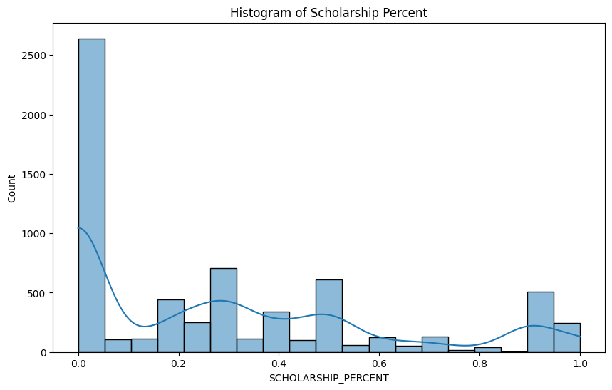

```python
# Histogram of SCHOLARSHIP_PERCENT
plt.figure(figsize=(10, 6))
sns.histplot(df['SCHOLARSHIP_PERCENT'], kde=True)
plt.title('Histogram of Scholarship Percent')
plt.show()
```

# Research Questions

The dataset guides the following research questions:

1. How do academic performance metrics, such as grades and absences, correlate with student retention as indicated by ESTATUS?
1. Can we predict student success based on their engagement in online courses, advisory, and counseling sessions?
1. What impact do scholarship percentages, financial standing (PASTDUE_BALANCE), and teacher evaluations have on student performance and retention?

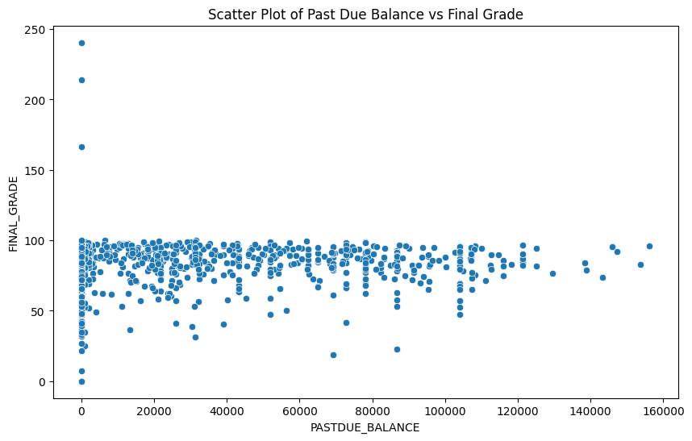

```python
# Scatter plot of PASTDUE_BALANCE vs FINAL_GRADE
plt.figure(figsize=(10, 6))
sns.scatterplot(x='PASTDUE_BALANCE', y='FINAL_GRADE', data=df)
plt.title('Scatter Plot of Past Due Balance vs Final Grade')
plt.show()
```

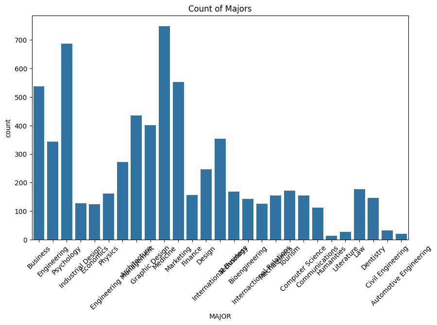

```python
# Bar plot for MAJOR
plt.figure(figsize=(10, 6))
sns.countplot(x='MAJOR', data=df)
plt.title('Count of Majors')
plt.xticks(rotation=45)
plt.show()
```

```python
# Frequency counts for SEMESTER
semester_counts = df['SEMESTER'].value_counts()
print("\nCounts in SEMESTER column:\n", semester_counts)
```

```
Counts in SEMESTER column:
 1     1907
4     1097
6      826
7      633
8      480
5      461
9      412
3      385
10     337
2       58
11       1
Name: SEMESTER, dtype: int64
```

# Preliminary Exploratory Analysis

Variable Roles Rationale:

Identification variables like ID are crucial for individual record tracking and are thus excluded from predictive modeling. Variables such as SEMESTER, MAJOR, GENDER, grades, and ABSENCES_* are pivotal predictors, offering insights into student performance trends and retention factors.

ESTATUS is a key outcome variable, representing the retention status of students.

Transforming DATA

```python
# Transform FINALEXAM_GRADE into a binary outcome variable
df['Academic_Success'] = (df['FINALEXAM_GRADE'] >= 94).astype(int)
```

```python
#Changing the gender variable to 0 or 1.
df['GENDER_CODED'] = df['GENDER'].map({'MALE': 0, 'FEMALE': 1})
```

```python
#Encoding the Origin variable
from sklearn.preprocessing import LabelEncoder
label_encoder = LabelEncoder()
df['ORIGIN_CODED'] = label_encoder.fit_transform(df['ORIGIN'])
```

We have transfrmed the data so that they better fit the models we are about to build.For academic excellence consider 94 and above as excellent. (Based on SPS grade system)

# Building predictive models

Logistic regression with LASSO

```python
from sklearn.model_selection import train_test_split
from sklearn.preprocessing import StandardScaler, OneHotEncoder
from sklearn.compose import ColumnTransformer
from sklearn.pipeline import Pipeline
from sklearn.impute import SimpleImputer
from sklearn.linear_model import LogisticRegression
from sklearn.metrics import accuracy_score, classification_report
from sklearn.ensemble import RandomForestClassifier, GradientBoostingClassifier

# Identify predictor variables - let's focus on demographics, grades, and teacher evaluations for now
# Assuming other relevant metrics can serve as proxies for engagement
predictor_columns = ['SEMESTER', 'GENDER_CODED', 'ORIGIN_CODED', 'FIRSTPART_GRADE', 'SECONDPARTIAL_GRADE', 'FINAL_GRADE'] + [f'TEACHEREVAL_Q{i}' for i in range(1, 17)]
X = df[predictor_columns]
y = df['Academic_Success']

# Splitting the dataset into training and testing sets
X_train, X_test, y_train, y_test = train_test_split(X, y, test_size=0.2, random_state=42)

# Defining the logistic regression model with LASSO (L1 penalty) again for clarity
lr_lasso_direct = LogisticRegression(penalty='l1', solver='liblinear', random_state=42)

# Fit the logistic regression model with LASSO using the previously preprocessed data
lr_lasso_direct.fit(X_train, y_train)

# Predict on the testing set using the directly preprocessed data
y_pred_lasso_direct = lr_lasso_direct.predict(X_test)

# Calculate accuracy and classification report for logistic regression with LASSO
accuracy_lasso_direct = accuracy_score(y_test, y_pred_lasso_direct)
classification_report_lasso_direct = classification_report(y_test, y_pred_lasso_direct)

accuracy_lasso_direct, classification_report_lasso_direct
```

```
(0.9409090909090909,
 '              precision    recall  f1-score   support\n\n           0       0.96      0.96      0.96       920\n           1       0.90      0.91      0.90       400\n\n    accuracy                           0.94      1320\n   macro avg       0.93      0.93      0.93      1320\nweighted avg       …
```

Random Forest classification.

```python
from sklearn.ensemble import RandomForestClassifier

# Define the Random Forest classifier
rf_classifier = RandomForestClassifier(n_estimators=100, random_state=42)

# Fit the Random Forest classifier using the final predictors
rf_classifier.fit(X_train, y_train)

# Predict on the testing set using the Random Forest classifier
y_pred_rf = rf_classifier.predict(X_test)

# Calculate accuracy and classification report for Random Forest classifier
accuracy_rf = accuracy_score(y_test, y_pred_rf)
classification_report_rf = classification_report(y_test, y_pred_rf)

accuracy_rf, classification_report_rf
```

```
(0.9363636363636364,
 '              precision    recall  f1-score   support\n\n           0       0.95      0.96      0.95       920\n           1       0.90      0.89      0.89       400\n\n    accuracy                           0.94      1320\n   macro avg       0.93      0.92      0.92      1320\nweighted avg       …
```

Support Vecortor Model

#### We will first build a bivariate plot to see what kind of kernel would work best for us.

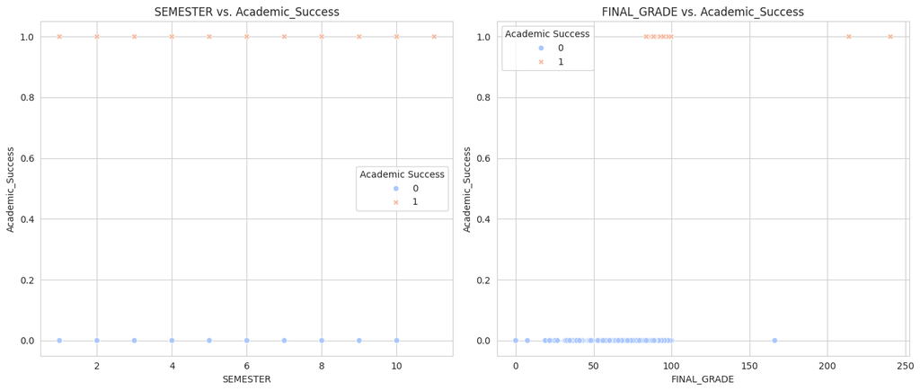

```python
import matplotlib.pyplot as plt
import seaborn as sns

# Setting the aesthetic style of the plots
sns.set_style("whitegrid")

# Creating bivariate plots
fig, ax = plt.subplots(1, 2, figsize=(14, 6))

# SEMESTER vs. Academic_Success
sns.scatterplot(data=df, x='SEMESTER', y='Academic_Success', ax=ax[0], hue='Academic_Success', style='Academic_Success', palette='coolwarm')
ax[0].set_title('SEMESTER vs. Academic_Success')
ax[0].set_xlabel('SEMESTER')
ax[0].set_ylabel('Academic_Success')
ax[0].legend(title='Academic Success')

# FINAL_GRADE vs. Academic_Success
sns.scatterplot(data=df, x='FINAL_GRADE', y='Academic_Success', ax=ax[1], hue='Academic_Success', style='Academic_Success', palette='coolwarm')
ax[1].set_title('FINAL_GRADE vs. Academic_Success')
ax[1].set_xlabel('FINAL_GRADE')
ax[1].set_ylabel('Academic_Success')
ax[1].legend(title='Academic Success')

plt.tight_layout()
plt.show()
```

```python
from sklearn.svm import SVC

# Define the SVM model with a linear kernel
svm_linear = SVC(kernel='linear', random_state=42)

# Fit the SVM model to the training data
svm_linear.fit(X_train, y_train)

# Predict on the testing set
y_pred_svm_linear = svm_linear.predict(X_test)

# Calculate accuracy and classification report for SVM with a linear kernel
accuracy_svm_linear = accuracy_score(y_test, y_pred_svm_linear)
classification_report_svm_linear = classification_report(y_test, y_pred_svm_linear)

accuracy_svm_linear, classification_report_svm_linear
```

```
(0.9416666666666667,
 '              precision    recall  f1-score   support\n\n           0       0.96      0.96      0.96       920\n           1       0.90      0.91      0.90       400\n\n    accuracy                           0.94      1320\n   macro avg       0.93      0.93      0.93      1320\nweighted avg       …
```

# Assessing model performance

```python
from sklearn.model_selection import GridSearchCV
from sklearn.linear_model import LogisticRegression

# Logistic Regression with LASSO hyperparameter tuning
lr_lasso_params = {'C': [0.01, 0.1, 1, 10, 100]}

# Directly using LogisticRegression with LASSO for GridSearchCV
lr_model = LogisticRegression(penalty='l1', solver='liblinear', random_state=42)

# GridSearchCV for Logistic Regression with LASSO, without a pipeline
lr_grid_search = GridSearchCV(lr_model, lr_lasso_params, cv=5, scoring='accuracy')

# Fit the model using the grid search
lr_grid_search.fit(X_train, y_train)  # Ensure X_train_final is preprocessed if necessary

# Retrieve the best parameters and the best score from the grid search
lr_best_params = lr_grid_search.best_params_
lr_best_score = lr_grid_search.best_score_

print("Best Parameters:", lr_best_params)
print("Best Score:", lr_best_score)
```

```
Best Parameters: {'C': 100}
Best Score: 0.9454240269998564
```

```python
# Random Forest hyperparameter tuning
rf_params = {
    'n_estimators': [100, 200, 300],
    'max_depth': [None, 10, 20, 30]
}
rf_grid_search = GridSearchCV(RandomForestClassifier(random_state=42), rf_params, cv=5, scoring='accuracy')
rf_grid_search.fit(X_train, y_train)

# Best parameters and best score for Random Forest
rf_best_params = rf_grid_search.best_params_
rf_best_score = rf_grid_search.best_score_

rf_best_params, rf_best_score
```

```
({'max_depth': 10, 'n_estimators': 300}, 0.9439090550050266)
```

```python
# SVM with linear kernel hyperparameter tuning
svm_params = {'C': [0.01, 0.1, 1, 10, 100]}
svm_grid_search = GridSearchCV(SVC(kernel='linear', random_state=42), svm_params, cv=5, scoring='accuracy')
svm_grid_search.fit(X_train, y_train)

# Best parameters and best score for SVM with linear kernel
svm_best_params = svm_grid_search.best_params_
svm_best_score = svm_grid_search.best_score_

svm_best_params, svm_best_score
```

```
({'C': 0.01}, 0.9473194025563695)
```

```python
# Initialize the model with the best parameters
lr_best = LogisticRegression(penalty='l1', solver='liblinear', C=100, random_state=42)

# Fit the model
lr_best.fit(X_train, y_train)

# Predict on the testing set
y_pred_lr = lr_best.predict(X_test)

# Evaluate the model
lr_test_accuracy = accuracy_score(y_test, y_pred_lr)
print("Logistic Regression Testing Accuracy:", lr_test_accuracy)
```

```
Logistic Regression Testing Accuracy: 0.9416666666666667
```

```python
# Initialize the model with the best parameters
rf_best = RandomForestClassifier(max_depth=10, n_estimators=300, random_state=42)

# Fit the model
rf_best.fit(X_train, y_train)

# Predict on the testing set
y_pred_rf = rf_best.predict(X_test)

# Evaluate the model
rf_test_accuracy = accuracy_score(y_test, y_pred_rf)
print("Random Forest Testing Accuracy:", rf_test_accuracy)
```

```
Random Forest Testing Accuracy: 0.9378787878787879
```

```python
# Initialize the model with the best parameters
svm_best = SVC(kernel='linear', C=0.01, random_state=42)

# Fit the model
svm_best.fit(X_train, y_train)

# Predict on the testing set
y_pred_svm = svm_best.predict(X_test)

# Evaluate the model
svm_test_accuracy = accuracy_score(y_test, y_pred_svm)
print("SVM Testing Accuracy:", svm_test_accuracy)
```

```
SVM Testing Accuracy: 0.9401515151515152
```

# Reporting results

Results for Logistic regression.

```python
print("Logistic Regression (LASSO) Optimal Hyperparameters:", lr_grid_search.best_params_)
y_pred_lr = lr_best.predict(X_test)
tn_lr, fp_lr, fn_lr, tp_lr = confusion_matrix(y_test, y_pred_lr).ravel()
accuracy_lr = accuracy_score(y_test, y_pred_lr)
print("Accuracy:", accuracy_lr)
print("TP:", tp_lr)
print("TN:", tn_lr)
print("FP:", fp_lr)
print("FN:", fn_lr, "\n")
```

```
Logistic Regression (LASSO) Optimal Hyperparameters: {'C': 100}
Accuracy: 0.9416666666666667
TP: 362
TN: 881
FP: 39
FN: 38
```

Results for Random forest

```python
print("Random Forest Optimal Hyperparameters:", rf_grid_search.best_params_)
y_pred_rf = rf_best.predict(X_test)
tn_rf, fp_rf, fn_rf, tp_rf = confusion_matrix(y_test, y_pred_rf).ravel()
accuracy_rf = accuracy_score(y_test, y_pred_rf)
print("Accuracy:", accuracy_rf)
print("TP:", tp_rf)
print("TN:", tn_rf)
print("FP:", fp_rf)
print("FN:", fn_rf, "\n")
```

```
Random Forest Optimal Hyperparameters: {'max_depth': 10, 'n_estimators': 300}
Accuracy: 0.9378787878787879
TP: 357
TN: 881
FP: 39
FN: 43
```

Results for SVM

```python
print("SVM (Linear Kernel) Optimal Hyperparameters:", svm_grid_search.best_params_)
y_pred_svm = svm_best.predict(X_test)
tn_svm, fp_svm, fn_svm, tp_svm = confusion_matrix(y_test, y_pred_svm).ravel()
accuracy_svm = accuracy_score(y_test, y_pred_svm)
print("Accuracy:", accuracy_svm)
print("TP:", tp_svm)
print("TN:", tn_svm)
print("FP:", fp_svm)
print("FN:", fn_svm)
```

```
SVM (Linear Kernel) Optimal Hyperparameters: {'C': 0.01}
Accuracy: 0.9401515151515152
TP: 360
TN: 881
FP: 39
FN: 40
```

## Variable Importance

```python
# Variable Importance (Coefficient magnitude)
coefficients = lr_grid_search.best_estimator_.coef_.flatten()
features = X.columns
feature_importance_lr = pd.Series(coefficients, index=features).sort_values(key=abs, ascending=False)
print("Feature importance for Logistic Regression:\n", feature_importance_lr)
```

```
Feature importance for Logistic Regression:
 SECONDPARTIAL_GRADE    0.484408
FINAL_GRADE            0.458688
FIRSTPART_GRADE        0.455695
TEACHEREVAL_Q10        0.402488
TEACHEREVAL_Q5        -0.328571
TEACHEREVAL_Q4        -0.285978
TEACHEREVAL_Q6         0.216492
TEACHEREVAL_Q7         0.203070
GENDER_CODED          -0.174262
TEACHEREVAL_Q15       -0.166357
TEACHEREVAL_Q9         0.161309
TEACHEREVAL_Q1         0.134420
TEACHEREVAL_Q13        0.129905
TEACHEREVAL_Q8        -0.119035
TEACHEREVAL_Q12        0.087776
TEACHEREVAL_Q16       -0.086609
ORIGIN_CODED          -0.072180
TEACHEREVAL_Q14       -0.041792
TEACHEREVAL_Q11        0.041203
TEACHEREVAL_Q2        -0.008282
TEACHEREVAL_Q3         0.005137
SEMESTER              -0.002574
dtype: float64
```

```python
# Variable Importance
importances_rf = rf_grid_search.best_estimator_.feature_importances_
feature_importance_rf = pd.Series(importances_rf, index=features).sort_values(ascending=False)
print("Feature importance for Random Forest:\n", feature_importance_rf)
```

```
Feature importance for Random Forest:
 FIRSTPART_GRADE        0.329153
SECONDPARTIAL_GRADE    0.310491
FINAL_GRADE            0.250413
GENDER_CODED           0.010156
SEMESTER               0.009450
TEACHEREVAL_Q3         0.007033
TEACHEREVAL_Q4         0.006581
TEACHEREVAL_Q5         0.006493
TEACHEREVAL_Q2         0.006491
TEACHEREVAL_Q7         0.006345
TEACHEREVAL_Q8         0.006009
TEACHEREVAL_Q6         0.005593
TEACHEREVAL_Q12        0.005407
TEACHEREVAL_Q9         0.005346
TEACHEREVAL_Q11        0.004914
TEACHEREVAL_Q1         0.004801
TEACHEREVAL_Q16        0.004737
TEACHEREVAL_Q13        0.004716
TEACHEREVAL_Q15        0.004486
TEACHEREVAL_Q14        0.004478
TEACHEREVAL_Q10        0.004381
ORIGIN_CODED           0.002526
dtype: float64
```

```python
# Assuming svm_best is your trained SVM model with a linear kernel
svm_coefficients = svm_best.coef_[0]

# Assuming X_train is your training dataset
feature_names = X_train.columns  # Make sure this reflects the actual features used

# Pairing feature names with coefficients
svm_feature_importance = zip(feature_names, svm_coefficients)

# Sorting features by absolute value of coefficient to understand their importance
sorted_svm_feature_importance = sorted(svm_feature_importance, key=lambda x: abs(x[1]), reverse=True)

# Displaying feature importance
print("Feature Importance from SVM (Linear Kernel):")
for feature, coef in sorted_svm_feature_importance:
    print(f"{feature}: {coef}")
```

```
Feature Importance from SVM (Linear Kernel):
SECONDPARTIAL_GRADE: 0.3261771634025532
FIRSTPART_GRADE: 0.31880246590057526
FINAL_GRADE: 0.30918710651197223
TEACHEREVAL_Q10: 0.12080530855445804
TEACHEREVAL_Q4: -0.10239323214679324
TEACHEREVAL_Q6: 0.10176641896327926
TEACHEREVAL_Q5: -0.09106142147354807
TEACHEREVAL_Q1: 0.054874837975937285
TEACHEREVAL_Q9: 0.054307317538216604
TEACHEREVAL_Q12: 0.044376910088410326
TEACHEREVAL_Q2: -0.03903677602147626
GENDER_CODED: -0.03651410030724721
TEACHEREVAL_Q7: 0.03491824984921976
TEACHEREVAL_Q16: 0.0251672385856907
TEACHEREVAL_Q14: -0.024475121916851028
TEACHEREVAL_Q13: 0.023397404938901745
TEACHEREVAL_Q8: -0.023143359045739054
TEACHEREVAL_Q15: -0.0141029997623896
TEACHEREVAL_Q3: 0.010536529444604592
TEACHEREVAL_Q11: 0.010415294940562259
SEMESTER: -0.0072081612656983984
ORIGIN_CODED: -0.0059343948511717814
```

```python
from sklearn.metrics import classification_report

# For Logistic Regression
print("Classification Report for Logistic Regression:")
print(classification_report(y_test, y_pred_lr))

# For Random Forest
print("Classification Report for Random Forest:")
print(classification_report(y_test, y_pred_rf))

# For SVM
print("Classification Report for SVM:")
print(classification_report(y_test, y_pred_svm))
```

```
Classification Report for Logistic Regression:
              precision    recall  f1-score   support

           0       0.96      0.96      0.96       920
           1       0.90      0.91      0.90       400

    accuracy                           0.94      1320
   macro avg       0.93      0.93      0.93      1320
weighted avg       0.94      0.94      0.94      1320

Classification Report for Random Forest:
              precision    recall  f1-score   support

           0       0.95      0.96      0.96       920
           1       0.90      0.89      0.90       400

    accuracy                           0.94      1320
   macro avg       0.93      0.93      0.93      1320
weighted avg       0.94      0.94      0.94      1320

Classification Report for SVM:
              precision    recall  f1-score   support

           0       0.96      0.96      0.96       920
           1       0.90      0.90      0.90       400

    accuracy                           0.94      1320
   macro avg       0.93      0.93      0.93      1320
weighted avg       0.94      0.94      0.94      1320
```

With the feature importance data for each of the three models—Logistic Regression with LASSO, Random Forest, and SVM with a Linear Kernel—you now have detailed insights into which features are most influential in predicting your target variable across different modeling approaches. Let's summarize and provide a brief analysis of what these importance rankings might indicate.

### Summary of Feature Importance Across Models

**Common Trends:**

- **Grades (`FIRSTPART_GRADE`, `SECONDPARTIAL_GRADE`, `FINAL_GRADE`)** consistently emerge as top predictors across all models, underscoring their critical role in determining academic success. This suggests that performance in assessments is a strong indicator of overall academic achievement, which aligns well with educational intuition.
- **Teacher evaluations (`TEACHEREVAL_Q*`)** vary in their importance across models, but certain questions (like Q10 in Logistic Regression and SVM) are highlighted as significant in multiple models. This variation suggests that specific aspects of teacher evaluations may have nuanced impacts on academic success.

### Choosing Metrics for Model Comparison

Given these insights, when comparing models, especially in an educational context where decisions could significantly impact students' academic trajectories, it's crucial to consider metrics beyond accuracy:

- **Precision and Recall**: Given the potential costs associated with false positives (e.g., incorrectly predicting academic success) and false negatives (failing to identify students at risk), balancing precision and recall becomes essential.
- **F1-Score**: Offers a balance between precision and recall, useful when you seek a harmonic mean of these metrics.

### Contextual Considerations

- The **decision context** (e.g., resource allocation for academic support, early intervention programs) might prioritize avoiding false negatives (failing to support students who need intervention) over false positives (providing extra support to students who might not need it), making recall a particularly relevant metric.
- **Variable importance** provides insights for policy and intervention, suggesting areas (like specific aspects of teaching quality or assessment performance) where targeted improvements or interventions could be most effective.

In summary, the optimal choice of metrics and the interpretation of feature importance should be aligned with the specific objectives and stakes of the educational decisions informed by these models.

# **Conclusion**

Given the classification reports for the Logistic Regression with LASSO, Random Forest, and SVM with a Linear Kernel, we observe remarkably similar performance across all three models in terms of precision, recall, and f1-score for both the positive (1) and negative (0) classes, as well as overall accuracy. This provides a nuanced perspective for model selection and recommendation.

### Key Observations:

- **Overall Accuracy**: All three models exhibit an accuracy of 94%, demonstrating high effectiveness in predicting academic success.
- **Precision and Recall**: The precision and recall for identifying academically successful students (1) and those not identified as such (0) are closely matched across models, with slight variations in the second decimal place not likely to be significant in practice.
- **F1-Score**: Reflects a balanced harmonic mean of precision and recall, reinforcing the close performance of these models in handling both classes effectively.

### Recommendations:

Given the uniformity in predictive performance:

1. **For the "best" predictive performance**: The choice between models becomes less about statistical metrics, as all three perform similarly, and more about other factors such as interpretability, computational efficiency, and ease of integration into existing processes. Given the negligible difference in precision, recall, and f1-score, **Logistic Regression with LASSO** might edge out slightly as preferable due to its interpretability and simplicity, especially valuable in settings where understanding the influence of specific predictors is crucial.
2. **For a good enough solution quickly**: While all models show comparable performance, **Logistic Regression with LASSO** stands out for its computational efficiency and ease of explanation. It provides a "quick" solution without sacrificing quality, making it ideal for scenarios requiring rapid development and deployment. Logistic Regression is inherently simpler and faster to train than Random Forest and SVM, particularly for large datasets or under computational constraints.

### Conclusion on Variable Importance:

The close performance also suggests that the primary predictors (grades and teacher evaluations) have a linear or nearly linear relationship with the outcome that all models can capture effectively. The grades being consistently significant across models highlights their universal importance in predicting academic success, reinforcing the value of focusing on academic performance as a key indicator.

### Final Recommendation:

- **For maximizing predictive performance with interpretability**: **Logistic Regression with LASSO** is recommended. Its performance is on par with more complex models, and it offers added benefits in terms of simplicity, interpretability, and computational efficiency.
- **In computationally constrained environments or under tight deadlines**, Logistic Regression with LASSO again proves to be an optimal choice, offering a robust solution that balances performance with practicality.

This analysis underscores the importance of considering model performance in conjunction with operational and interpretational factors, especially when predictive accuracies are closely matched.